# Confidence Intervals and Effect Sizes

September 21, 2021

## Announcements

- Grades are posted for HW2
  - Solution sheet will be available on Moodle on Wed
- HW3 posted
- In-person Office hours (Bass 412)
  - Wed 10:50-12:05p (Zoom this week!)
  - Thurs 1:20-2:35p
  - or by appointment
- Zoom Office hours are full
- Where to get HW help
  - [Spinelli center](https://www.smith.edu/qlc/tutoring.html) tutoring Sun-Thurs 7-9p, Sabin-Reed 301.

## Agenda

- Transformations
- Confidence intervals
- Effect sizes
- MP1 introduction
  - topics time

## Last time

### How to check assumptions

- C. **Constant effects** – *think* about whether it is reasonable.
- A. **Additive effects** – *think* about whether it is reasonable.
- S. **Same standard deviations** – is the biggest SD less than two times as large as the smallest?
- I. **Independent residuals** – *think* about whether it is reasonable.
- N. **Normally distributed residuals** – construct a histogram or normal probability plot of residuals.
- Z. **Zero mean residuals** – construct a histogram or normal probability plot of residuals.

## Transformations: Example

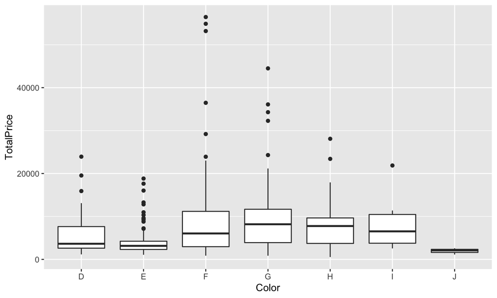

```r
library(Stat2Data)
library(tidyverse)
data("Diamonds")

qplot(x = Color, y = TotalPrice, data = Diamonds, geom = "boxplot")
```

## Transformations: Example

```r
Diamonds %>%
  group_by(Color) %>%
  summarise(n = n(),
            m = mean(TotalPrice, na.rm = TRUE),
            sd = sd(TotalPrice, na.rm = TRUE))
```

```
## # A tibble: 7 x 4
##   Color     n     m     sd
##   <fct> <int> <dbl>  <dbl>
## 1 D        52 5569.  4764.
## 2 E        82 4359.  3696.
## 3 F        87 9160. 10937.
## 4 G        86 9559.  7993.
## 5 H        29 8669.  6379.
## 6 I        12 7640.  5461.
## 7 J         3 1936.   737.
```

```r
10937/736 #Yikes!
```

```
## [1] 14.86005
```

## Transformations: Example

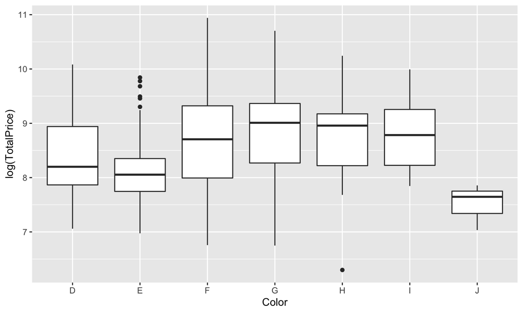

```r
qplot(x = Color, y = log(TotalPrice), data = Diamonds, geom = "boxplot")
```

## Common transformations

For the response (Y)…

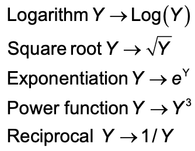

## How to transform

We can do the transformation directly in the visualization code:

```r
qplot(x = Color, y = log(TotalPrice), data = Diamonds, geom = "boxplot")
```

OR, we can create a new variable in the dataset

```r
Diamonds <- Diamonds %>%
  mutate(ln_TotalPrice = log(TotalPrice))

#Then, we use the new variable to make our visualization
qplot(x = Color, y = ln_TotalPrice, data = Diamonds, geom = "boxplot")
```

## When to use log transformation:

Look for:

- Distribution of response is skewed towards high end.
- The responses in one group (or more) range over two or more orders of magnitude.
- Variability varies across groups considerably, especially when the spread tracks with the mean.

## Diagnostic plot to pick a transformation

Steps:

1. Save the means and sd’s of groups in a little **dataset**.
2. Make a scatterplot of log(sd) versus log(m) with a **line of best fit**.
3. Your transformation will be the response raised to the **power of 1-slope** of that line.

## Diagnostic plot to pick a transformation: Step 1

Save the means and sd’s of groups in a little **dataset**.

```r
ds <- Diamonds %>%
  group_by(Color) %>%
  summarise(n = n(),
            m = mean(TotalPrice),
            sd = sd(TotalPrice))
```

## Diagnostic plot to pick a transformation: Step 2

Make a scatterplot of log(sd) versus log(m) with a **line of best fit**.

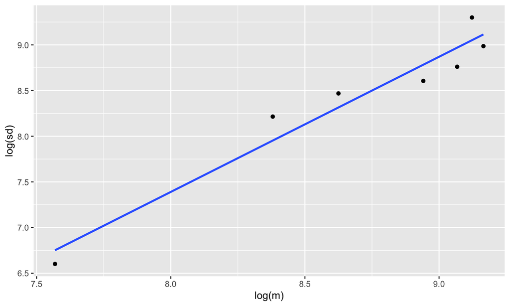

```r
qplot(x = log(m), y = log(sd), data = ds) +
  geom_smooth(method = lm, se = 0)
```

## Diagnostic plot to pick a transformation: Step 3

Your transformation will be the response raised to the **power of 1-slope** of that line.

```r
lm(log(sd) ~ log(m), data = ds)
```

```
##
## Call:
## lm(formula = log(sd) ~ log(m), data = ds)
##
## Coefficients:
## (Intercept)       log(m)
##      -4.447        1.480
```

## Diagnostic plot to pick a transformation: Step 3

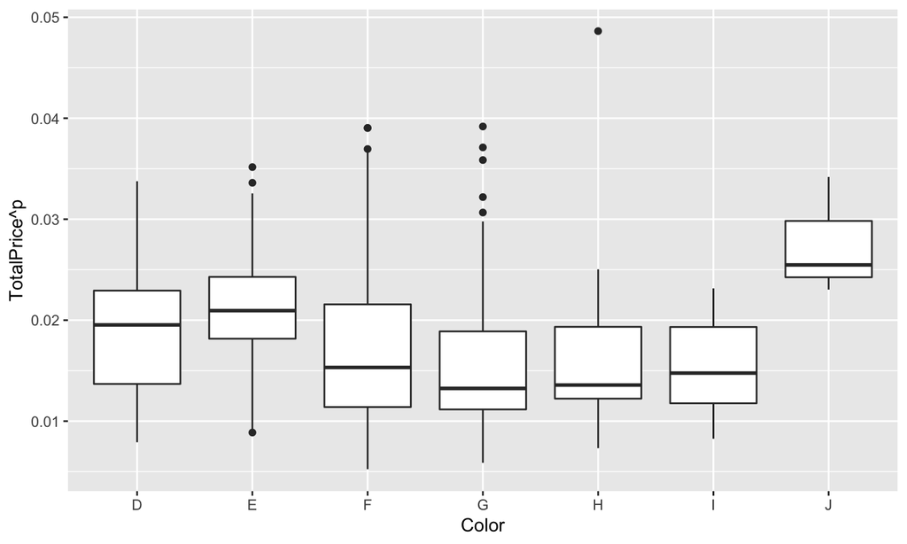

```r
p = 1 - 1.480

qplot(x = Color, y = TotalPrice^p, data = Diamonds, geom = "boxplot")
```

## Try it for the Hawks (from HW2)!

```r
library(Stat2Data)
data("Hawks")
```

- Find a transformation that helps the heterogeneity of variance for Y = Weight and X = Species.
- Run the ANOVA (even if the issue is not completely fixed) and write a sentence interpretation of your ANOVA results.

Steps for finding a transformation:

1. Save the means and sd’s of groups in a little **dataset**.
2. Make a scatterplot of log(sd) versus log(m) with a **line of best fit**.
3. Your transformation will be the response raised to the **power of 1-slope** of that line.

## ANOVA for Diamonds

```r
modDia <- lm(log(TotalPrice) ~ Color, data = Diamonds)
anova(modDia)
```

```
## Analysis of Variance Table
##
## Response: log(TotalPrice)
##            Df  Sum Sq Mean Sq F value    Pr(>F)
## Color       6  29.946  4.9909  7.3713 1.972e-07 ***
## Residuals 344 232.913  0.6771
## ---
## Signif. codes:  0 '***' 0.001 '**' 0.01 '*' 0.05 '.' 0.1 ' ' 1
```

There are statistically significant differences in log price of diamonds across colors \(F(6, 344) = 7.37\), \(p < .001\).

But what else do we want to know??

## Effect Sizes and Confidence Intervals

- The p-value for our F-ratio only tells us if effects are **detectable**.
  - Answers the question: **IS there an effect?**
- Practical significance is different from **statistical** significance.
  - Need to answer the question: **How big is IT**?
- Which values in ANOVA do we want to construct confidence intervals for (or calculate an effect size for)?

### Some options:

- A specific group mean.
- How far away a specific condition is from the grand average (the treatment effect).
- How far away a specific condition is from another condition.
- How far away a specific condition (or set of conditions) is(are) from a(nother) set of conditions.
- Additional effect size option: The overall variance explained by a factor of interest.

## Effect Sizes and Confidence Intervals

- The p-value for our F-ratio only tells us if effects are **detectable**.
  - Answers the question: **IS** there an effect?
- Practical significance is different from **statistical** significance.
  - Need to answer the question: How big is **IT**?
- Which values in ANOVA do we want to construct confidence intervals for (or calculate an effect size for)?

Some options:

- A specific group mean.
- How far away a specific condition is from the grand average (the treatment effect).
- **How far away a specific condition is from another condition.**
- How far away a specific condition (or set of conditions) is(are) from a(nother) set of conditions.
- Additional effect size option: The overall variance explained by a factor of interest.

## Confidence Intervals for Difference Between two Groups

\[(\bar{y_i}-\bar{y_j}) \pm t^*\cdot SD \sqrt{1/n_i+1/n_j}\]

- Where \(SD = \sqrt{MSE}\).
- \(t^*\) depends on the confidence level and df of the error.
- \(Sample\:size\:factor = \sqrt{1/n_i+1/n_j}\), the larger the sample sizes, the narrower the interval.
- \(\sqrt{{MS}_{res}}*leverage\) is the standard error of the estimate.
- \(t({df}_{res})\) is the t-value the dictates distance of the interval.

## Calculating CI between groups in R

\[(\bar{y_G}-\bar{y_F}) \pm t^*\cdot SD \sqrt{1/n_G+1/n_F}\]

For difference between G (near colorless) and F (colorless)

```r
MSE = 0.6771 #from our ANOVA source table
df_E = 344 #from our ANOVA source table
t <- qt(.975, df_E) #for 95% CI

n_g = filter(ds, Color == "G")$n #sample size for G
n_f = filter(ds, Color == "F")$n #sample size for F

mean_g <- log(filter(ds, Color == "G")$m) #mean for G
mean_f <- log(filter(ds, Color == "F")$m) #mean for F

#Confidence interval
UL <- (mean_g-mean_f) + t*sqrt(MSE)*sqrt(1/n_g+1/n_f) #upper limit
LL <- (mean_g-mean_f) - t*sqrt(MSE)*sqrt(1/n_g+1/n_f) #lower limit
```

## Calculating CI between groups in R

For difference between G (near colorless) and F (colorless)

```r
LL
```

```
## [1] -0.2035213
```

```r
UL
```

```
## [1] 0.2886875
```

Sentence interpretation:

We are 95% confident that the true mean difference in (log) price between near colorless and colorless Diamonds is between -0.20 and 0.29.

## Equivalence of Confidence Intervals and Tests

> Two group means are statistically different at the 5% (1%) level if and only if a 95% (99%) confidence interval for their diffrence does not include 0.

## Effect Size (D)

But **how big is IT**?

We can compare the differences between groups to to the standard deviation within all groups:

\[D_{ij} = \frac{(\bar{y_i}-\bar{y_j})}{SD}\]

- Where again \(SD = \sqrt{MSE}\)

## Effect Size (D)

For difference between G (near colorless) and F (colorless)

```r
D = (mean_g-mean_f)/sqrt(MSE)

D
```

```
## [1] 0.05175002
```

The difference between the price of nearly colorless diamonds and colorless diamonds is only 0.052 times the size of the typical within-group deviations in price. Such a small difference!

## R-squared for One-Way ANOVA

But how much does color matter overall?

\(R^2\) is the proportion of total variation explained by the factor:

\[R^2 = \frac{SS_{treatment}}{SS_{Total}}\]

OR

\[R^2 = 1-\frac{SS_{error}}{SS_{total}}\]

## R-squared for Diamond Color

```r
modDia <- lm(log(TotalPrice) ~ Color, data = Diamonds)
anova(modDia)
```

```
## Analysis of Variance Table
##
## Response: log(TotalPrice)
##            Df  Sum Sq Mean Sq F value    Pr(>F)
## Color       6  29.946  4.9909  7.3713 1.972e-07 ***
## Residuals 344 232.913  0.6771
## ---
## Signif. codes:  0 '***' 0.001 '**' 0.01 '*' 0.05 '.' 0.1 ' ' 1
```

```r
R2 = 29.946/(29.946+232.913)
R2
```

```
## [1] 0.1139242
```

The \(R^2\) value is 0.11, so about 11% of the variation in the total price of a diamonds is explained by the diamonds’ colors.

## Try it!

Use the `SandwichAnts` dataset to calculate the CI and effect size for difference between `MultiGrain` and `Rye` in number of `Ants`.

## Mini Project 1

See [Mini Project 1 instructions](https://randilgarcia.github.io/sds290fall21/mini-project-1.html)